# Predicting Length of Stay for Patients

## 2. Exploratory Data Analysis

#### 2.1 Univariate Analysis

```
Descriptive statistics:
count    10999.000000
mean         1.435858
std          0.891275
min          1.000000
25%          1.000000
50%          1.000000
75%          1.000000
max          5.000000
Name: ReadmissionCount, dtype: float64
```

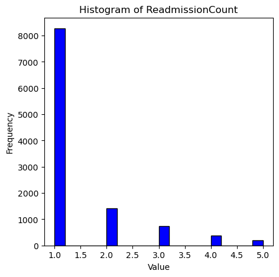

```
count     10999
unique        2
top           F
freq       6011
Name: Gender, dtype: object
```

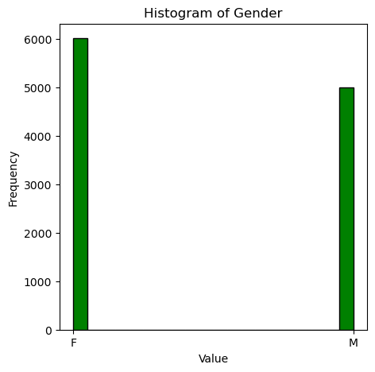

```
count    10999.000000
mean        29.059915
std          2.005955
min         19.800000
25%         27.700000
50%         29.000000
75%         30.400000
max         36.700000
Name: BMI, dtype: float64
```

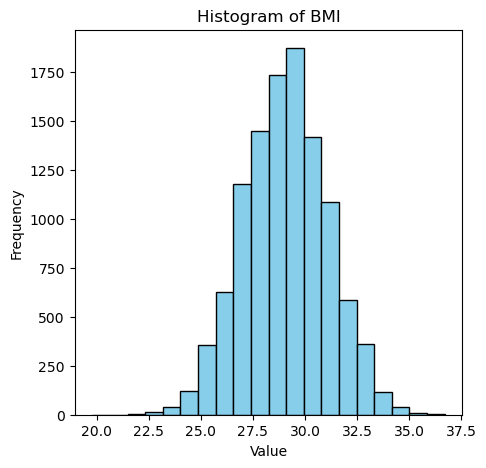

```
count    10999.000000
mean       142.644591
std         30.329310
min         -1.010000
25%        123.000000
50%        143.000000
75%        163.000000
max        253.000000
Name: ABG, dtype: float64
```

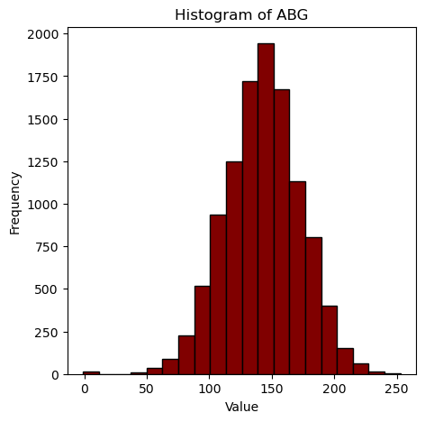

```
count    10999.000000
mean        77.751068
std         18.133906
min         10.000000
25%         65.000000
50%         78.000000
75%         90.000000
max        148.000000
Name: Pulse, dtype: float64
```

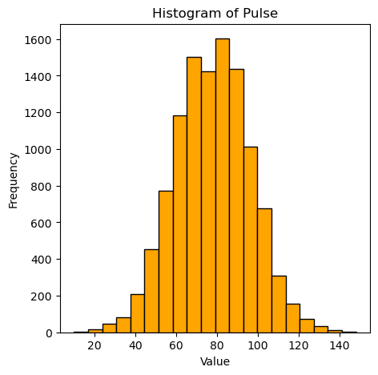

```
count    10999.000000
mean         2.415492
std          1.772709
min          0.000000
25%          1.000000
50%          2.000000
75%          3.000000
max         10.000000
Name: SecondaryDiagnosis, dtype: float64
```

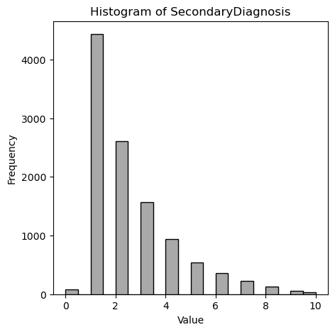

```python
# Display descriptive statistics for different features in the Data
print("Descriptive statistics:")

print(data['ReadmissionCount'].describe())
# Create a histogram for the Readmission Count
plt.figure(figsize=(5,5))
plt.hist(data['ReadmissionCount'], bins=20, color='blue', edgecolor='black')
plt.title('Histogram of ReadmissionCount')
plt.xlabel('Value')
plt.ylabel('Frequency')
plt.show()

print(data['Gender'].describe())
# Create a histogram for Gender Column
plt.figure(figsize=(5,5))
plt.hist(data['Gender'], bins=20, color='green', edgecolor='black')
plt.title('Histogram of Gender')
plt.xlabel('Value')
plt.ylabel('Frequency')
plt.show()

print(data['BMI'].describe())
# Create a histogram for Body Mass Index Column
plt.figure(figsize=(5,5))
plt.hist(data['BMI'], bins=20, color='skyblue', edgecolor='black')
plt.title('Histogram of BMI')
plt.xlabel('Value')
plt.ylabel('Frequency')
plt.show()

print(data['ABG'].describe())
# Create a histogram for Body Mass Index Column
plt.figure(figsize=(5,5))
plt.hist(data['ABG'], bins=20, color='maroon', edgecolor='black')
plt.title('Histogram of ABG')
plt.xlabel('Value')
plt.ylabel('Frequency')
plt.show()

print(data['Pulse'].describe())
# Create a histogram for Gender Column
plt.figure(figsize=(5,5))
plt.hist(data['Pulse'], bins=20, color='orange', edgecolor='black')
plt.title('Histogram of Pulse')
plt.xlabel('Value')
plt.ylabel('Frequency')
plt.show()

print(data['SecondaryDiagnosis'].describe())
# Create a histogram for Gender Column
plt.figure(figsize=(5,5))
plt.hist(data['SecondaryDiagnosis'], bins=20, color='darkgrey', edgecolor='black')
plt.title('Histogram of SecondaryDiagnosis')
plt.xlabel('Value')
plt.ylabel('Frequency')
plt.show()
```

#### Inferences:

1. Readmissing Count
   - Most patients get readmitted to the hospital only 1 other time. This could imply that either the patients admitted are not with very serious injuries/diseases or hospital care is very good that readmissions of patients are not necessary. It could also mean that patients are not happy with the care and they go to another hospital.
   - There are very few patients that need to be readmitted more number of times.
2. Gender
   - There are more female patients than there are male patients
3. Numerical Features: BMI, ABG and Pulse rate
   - There are 3 features BMI, ABG and Pulse that have no skew. There distribution is mostly normal with majority of the data situated around the mean.
   - Post patients have their BMI, ABG and Pulse levels normal.
4. Secondary Diagnosis
   - There are very few patients that don't have a secondary diagnosis. Most patients that are present in the data have atleast one other disease in addition to the reason they got admitted to this hospital.

#### 2.2 Bivariate Analysis

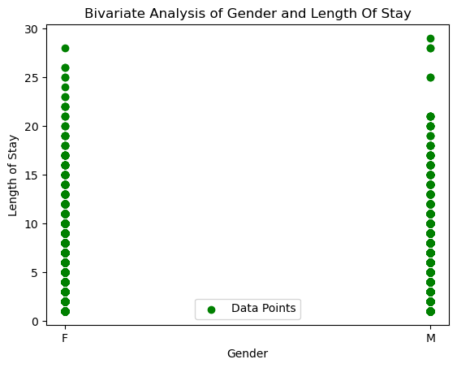

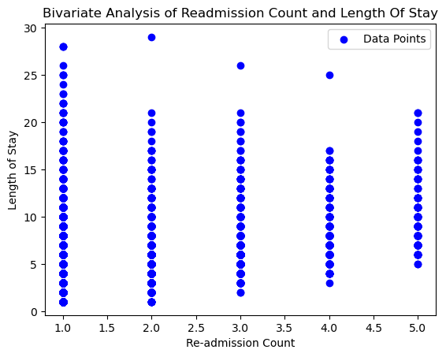

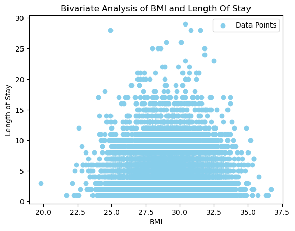

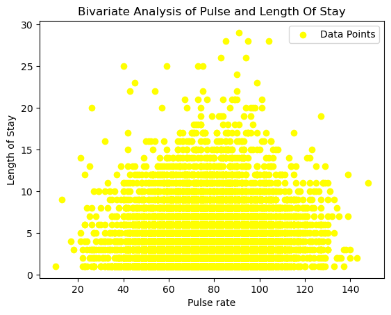

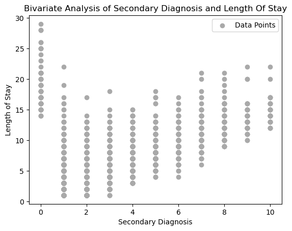

```python
df = pd.DataFrame(data)

# Scatter plot for Gender Vs LengthofStay
plt.scatter(df['Gender'], df['LengthOfStay'], color='green', label='Data Points')
plt.title('Bivariate Analysis of Gender and Length Of Stay')
plt.xlabel('Gender')
plt.ylabel('Length of Stay')
plt.legend()
plt.show()

# Scatter plot for ReadmissionCount Vs LengthofStay
plt.scatter(df['ReadmissionCount'], df['LengthOfStay'], color='blue', label='Data Points')
plt.title('Bivariate Analysis of Readmission Count and Length Of Stay')
plt.xlabel('Re-admission Count')
plt.ylabel('Length of Stay')
plt.legend()
plt.show()

# Scatter plot for BMI Vs LengthofStay
plt.scatter(df['BMI'], df['LengthOfStay'], color='skyblue', label='Data Points')
plt.title('Bivariate Analysis of BMI and Length Of Stay')
plt.xlabel('BMI')
plt.ylabel('Length of Stay')
plt.legend()
plt.show()

# Scatter plot for Pulse Vs LengthofStay
plt.scatter(df['Pulse'], df['LengthOfStay'], color='yellow', label='Data Points')
plt.title('Bivariate Analysis of Pulse and Length Of Stay')
plt.xlabel('Pulse rate')
plt.ylabel('Length of Stay')
plt.legend()
plt.show()


# Scatter plot for SecondaryDiagnosis Vs LengthofStay
plt.scatter(df['SecondaryDiagnosis'], df['LengthOfStay'], color='darkgrey', label='Data Points')
plt.title('Bivariate Analysis of Secondary Diagnosis and Length Of Stay')
plt.xlabel('Secondary Diagnosis')
plt.ylabel('Length of Stay')
plt.legend()
plt.show()
```